# Mussels

2022-11-25

## Function to gather observations

This function merges all files of the same extension from a given folder, the path to the folder is passed as a function argument

```r
data_aggregate <- function(path) {
  filenames <- list.files(path, pattern="*.csv")
  mussels <<- tibble()
  func <- function(x) {
    df <- read.csv(x)
    df[,2] <- as.factor(df[,2])
    mussels <<- rbind(mussels, df)
  }
  lapply(filenames, func)
  return("Data were aggregated")
}
```

#### Run function on current data

```r
data_aggregate("C:/Users/buyko/Desktop/BI_R_project/Data/Data")
```

```
## [1] "Data were aggregated"
```

## EDA

#### Renaming and changing the type of some variables and values correction in the “Sex” variable

The values of the sex variable were corrected (duplicate levels of the factor were removed)  
Rows with missing values were removed

```r
names <- colnames(mussels)
names[2] <- 'Sex'
colnames(mussels) <- names

levels(mussels$Sex)[c(1,6)] <- 'male'
levels(mussels$Sex)[2] <- 'female'
levels(mussels$Sex)[c(3, 4)] <- 'uvenil'


mussels$Length <- as.double(mussels$Length)
mussels$Rings <- as.integer(mussels$Rings)

mussels <- na.omit(mussels)
```

#### Visualising outliers

Numeric variables only

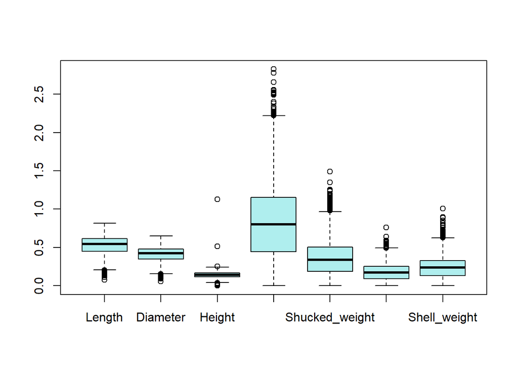

#### Assessment of the correlations between the variables

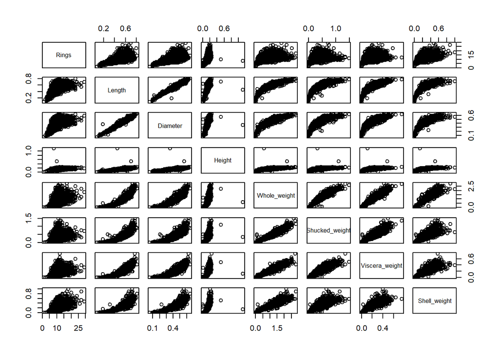

Two outliers significantly affecting the correlation of the Height variable were removed.

```r
boxplot.stats(mussels$Height)$out
```

```
##  [1] 0.030 0.015 0.020 0.250 0.030 0.030 0.030 0.000 0.025 0.025 0.515 0.015
## [13] 1.130 0.035 0.035 0.250 0.020 0.010 0.030 0.025 0.035 0.035 0.035 0.025
## [25] 0.250 0.025 0.000 0.030
```

```r
mussels$Height[mussels$Height %in% c(1.130, 0.515)] <- NA
mussels <- na.omit(mussels)
```

See how the interaction graphs have changed

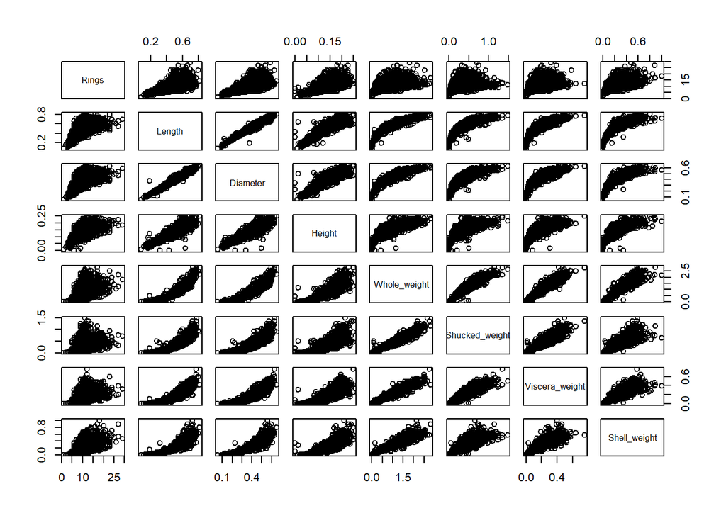

All numeric variables are directly related to each other  
Hypothesis:  
- A linear correlation between pairs of numeric variables  
- No differences between groups by the nominative variable “Sex”

## Mean value and standard deviation of the variable Length for clams of different sexes

```r
mussels %>% group_by(Sex) %>%
  summarise(mean=mean(Length), sd=sd(Length))
```

```
## # A tibble: 3 × 3
##   Sex     mean     sd
##   <fct>  <dbl>  <dbl>
## 1 male   0.561 0.103
## 2 female 0.580 0.0862
## 3 uvenil 0.428 0.109
```

## Percentage of clams, the value of the Height variable does not exceed 0.165

```r
sum(mussels$Height<=0.165)/4153*100
```

```
## [1] 75.87286
```

## Value of the variable Length, which is greater than 92% of all observations

```r
# 4153/100*92 = 3820.76
sort(mussels$Length)[3821]
```

```
## [1] 0.67
```

## Length z-standartization

```r
Length_mean <- mean(mussels$Length)
Length_sd <- sd(mussels$Length)
mussels$Lenght_z_scores <- (mussels$Length - Length_mean)/Length_sd
```

A new variable Lenght_z_scores was created. The values of the Length variable after standardization were saved in this variable

## Comparison of the diameter of clams with the number of rings 5 and 15

#### Selection of values suitable for the parameters and normality check

```r
mussels_5_15 <- mussels %>% select(Rings, Diameter) %>%
  filter(Rings==5 | Rings==15) %>%
  transmute(Rings=as.factor(Rings), Diameter)

by(mussels_5_15$Diameter, INDICES=mussels_5_15$Rings, shapiro.test)  #Shapiro–Wilk test
```

```
## mussels_5_15$Rings: 5
##
##  Shapiro-Wilk normality test
##
## data:  dd[x, ]
## W = 0.98192, p-value = 0.1269
##
## ------------------------------------------------------------
## mussels_5_15$Rings: 15
##
##  Shapiro-Wilk normality test
##
## data:  dd[x, ]
## W = 0.98227, p-value = 0.1836
```

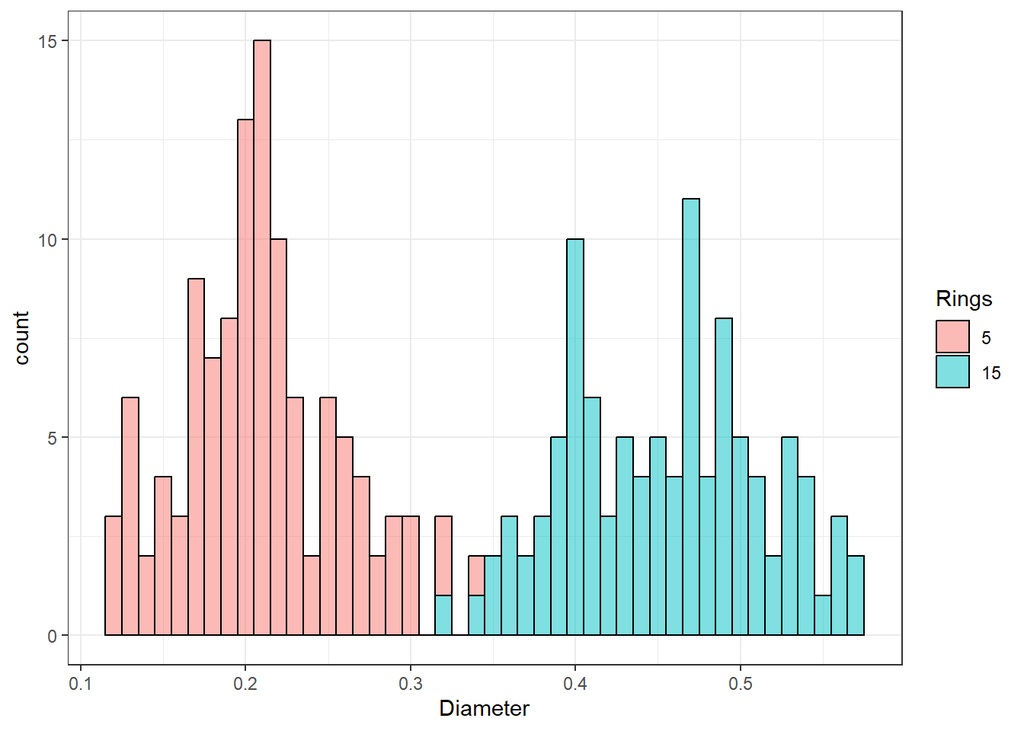

```r
ggplot(mussels_5_15, aes(Diameter, fill=Rings)) +
  geom_histogram(color='black', alpha=.5, binwidth=0.01)
```

The values within the groups are normally distributed

#### Comparison of group averages (t-test)

```r
df <- mussels_5_15 %>% group_by(Rings) %>%
  summarise(mean=round(mean(Diameter), digits=3), sd=round(sd(Diameter), digits=3))
df %>% transmute(Number_of_rings=Rings, Diameter=paste0(mean, "±", sd))
```

```
## # A tibble: 2 × 2
##   Number_of_rings Diameter
##   <fct>           <chr>
## 1 5               0.211±0.047
## 2 15              0.456±0.059
```

```r
test1 <- t.test(Diameter ~ Rings, mussels_5_15)
test1$p.value
```

```
## [1] 5.333556e-83
```

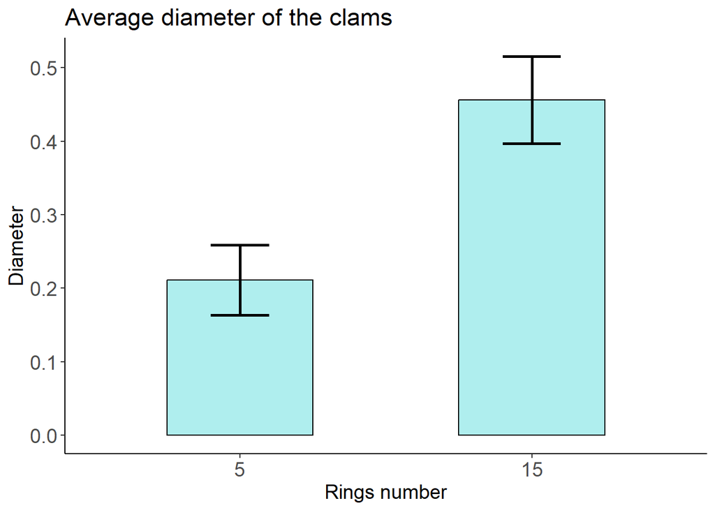

```r
p <- mussels_5_15 %>%
  group_by(Rings) %>%
  summarize(mean=mean(Diameter), sd=sd(Diameter)) %>%
  ggplot(aes(x=Rings, y=mean)) +
  geom_bar(stat="identity", color="black", fill='#AFEEEE',
           position=position_dodge(), width = 0.5) +
  geom_errorbar(aes(ymin=mean-sd, ymax=mean+sd), width=.2, linewidth=1,
                position=position_dodge(.9))
p+labs(title="Average diameter of the clams",
       x="Rings number", y = "Diameter")+
  theme_classic() +
  theme(axis.text = element_text(size = 14), axis.title = element_text(size = 14),
        title = element_text(size = 14))
```

## Relationship of the Diameter and Whole_weight variables

#### Correlation curve plotting

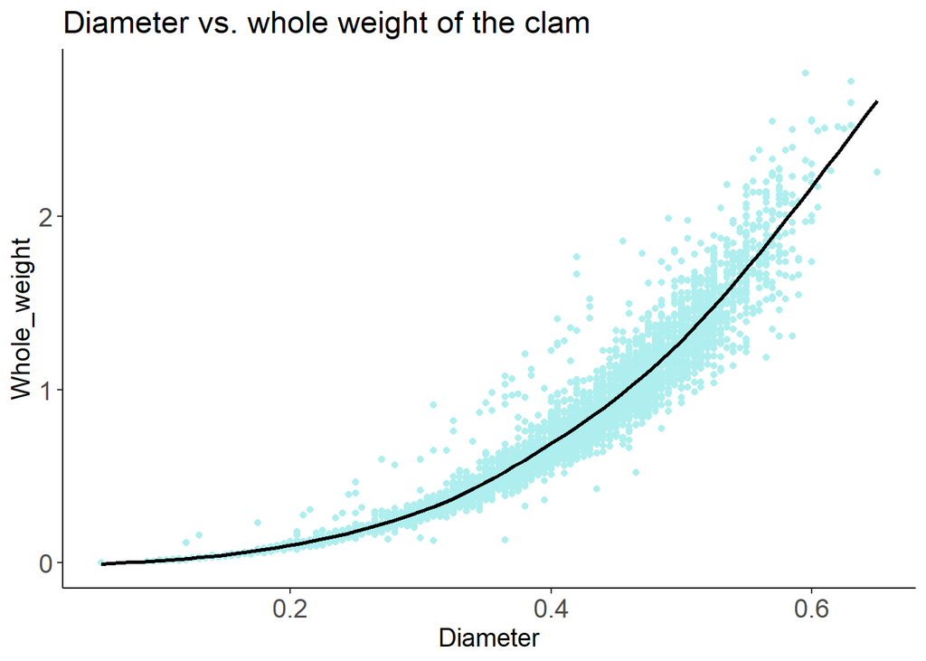

```r
ggplot(mussels, aes(x=Diameter, y=Whole_weight)) +
  geom_point(color='#AFEEEE') +
  geom_smooth(se = FALSE, color='black', linewidth=1) +
  labs(title="Diameter vs. whole weight of the clam") +
  theme_classic() +
  theme(axis.text = element_text(size = 14), axis.title = element_text(size = 14),
        title = element_text(size = 14))
```

#### Calculation of the correlation coefficient

```r
correlation_d_w <- cor.test(x = mussels$Diameter, y = mussels$Whole_weight)
correlation_d_w$estimate
```

```
##       cor
## 0.9257326
```

The correlation coefficient 0.926 (p-value < 2.2e-16, alternative hypothesis: true correlation is not equal to 0) and the correlation curve graph indicate a close relationship between Diameter and Whole_weight variables